```
## Gráficas generadas exitosamente
```

# Question

Sebastián lleva un registro detallado de los gastos relacionados con su carro. La tabla muestra los gastos semanales durante un mes completo, organizados por categorías.

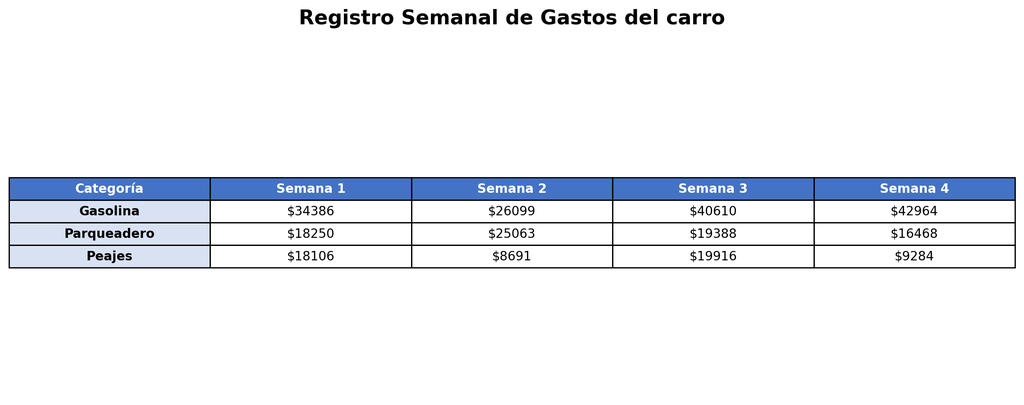

## Gráficas de análisis

A continuación se presentan cuatro tipos diferentes de gráficas que representan los mismos datos de la tabla:

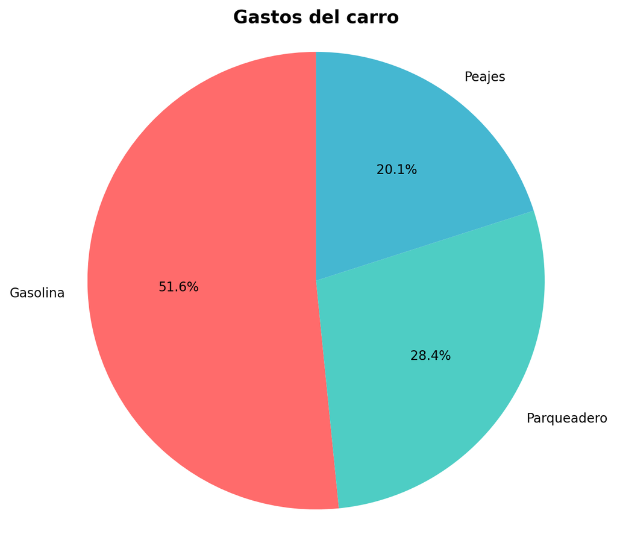

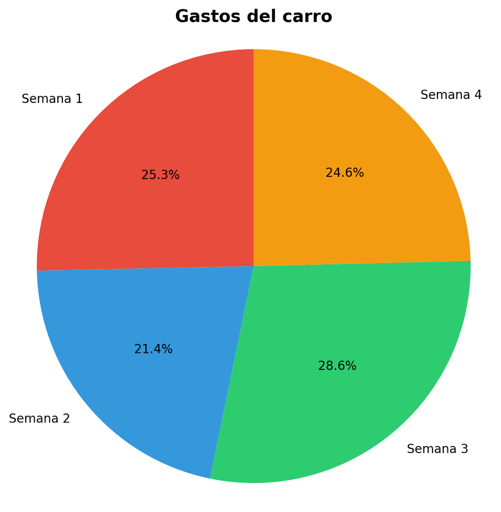

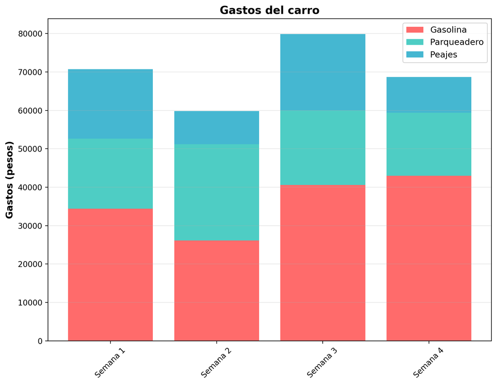

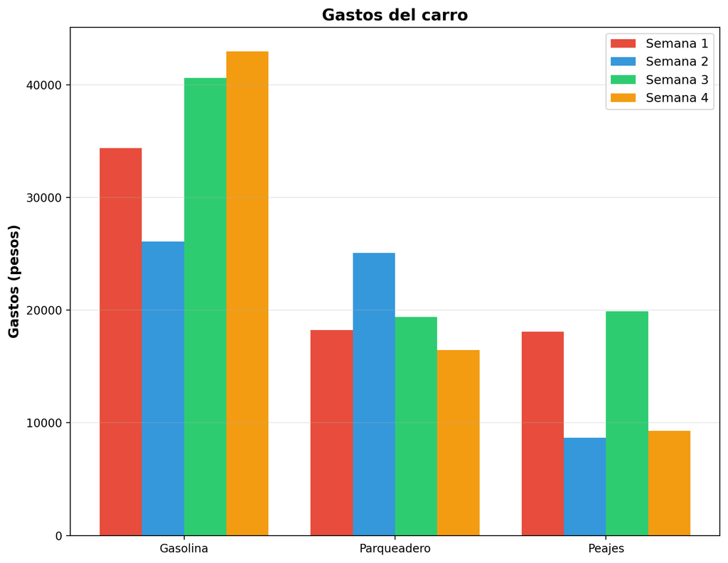

## Análisis paso a paso

Para analizar qué categoría representó el menor porcentaje del gasto total mensual, resuelva paso a paso:

**IMPORTANTE - Formato de números:**

- **Valores monetarios**: Sin separador de miles, use punto para decimales
  - Ejemplo: $16850.32 (no $16.850,32 ni $16850,32)
- **Respuestas numéricas**: Sin separador de miles, use punto para decimales
  - Ejemplo: 1234.5678 (no 1.234,5678 ni 1234,5678)

### Paso 1: Identificación del menor gasto por categoría

Observe la tabla y identifique cuál fue el menor gasto por categoría (total por categoría).

### Paso 2: Identificación del gasto total mensual

Según la tabla, ¿cuál es el gasto total del mes (suma de todas las semanas)?

### Paso 3: Configuración de la fórmula de porcentaje

Para calcular el porcentaje, complete la fórmula con los valores identificados:

### Paso 4: Verificación de valores

Confirme que los valores del numerador y denominador son correctos:

### Paso 5: Cálculo del porcentaje final

Complete el cálculo del porcentaje:

### Paso 6: Confirmación del tipo de gráfica (CON PUNTUACIÓN)

Basándose en su análisis anterior, **seleccione qué tipo de gráfica permite identificar más fácilmente qué categoría de gasto representa el mayor porcentaje del gasto total mensual**:

## Answerlist

# Solution

**NOTA IMPORTANTE - Configuración de evaluación automática:**

- **Tolerancias configuradas**: Tolerancia 1 para respuestas numéricas monetarias, tolerancia 0.1 para porcentajes, tolerancia 0 para respuestas schoice
- **Justificación**: Los valores monetarios son enteros grandes, tolerancia 1 evita rechazos incorrectos por diferencias mínimas de formato manteniendo precisión matemática
- **Formato numérico**: Sin separador de miles, punto como separador decimal

### Análisis paso a paso del problema de gastos de vehículo

Este problema de **interpretación de tablas** y **cálculo de porcentajes** requiere un análisis secuencial que demuestre el proceso de razonamiento matemático aplicado a contextos de gastos personales:

**NOTA IMPORTANTE - Formato de números estandarizado:**

- **Valores monetarios**: Sin separador de miles, use punto para decimales
  - Ejemplo: $16850.32 (no $16.850,32 ni $16850,32)
- **Respuestas numéricas**: Sin separador de miles, punto como separador decimal
  - Ejemplo: 1234.5678 (no 1.234,5678 ni 1234,5678)
- **Consistencia**: Mismo formato en enunciado, opciones y respuestas

### Paso 1: Identificación correcta del menor gasto por categoría ✓

**Respuesta correcta:** $55997

**Análisis de gastos por categoría:**

- Gasolina: $144059
- Parqueadero: $79169
- Peajes: $55997

La categoría Peajes tuvo el menor gasto con $55997.

### Paso 2: Identificación del gasto total mensual ✓

**Respuesta correcta:** $279225

El total mensual se calcula sumando todos los gastos semanales:

$$\text{Total mensual} = 70742 + 59853 +
79914 + 68716 = 279225$$

### Paso 3: Configuración correcta de la fórmula ✓

**Respuestas correctas:** Numerador = 55997, Denominador = 279225

La fórmula de porcentaje requiere:

- **Numerador:** El valor observado (55997 pesos)
- **Denominador:** El valor total (279225 pesos)

### Paso 5: Cálculo del porcentaje final ✓

**Respuesta correcta:** 20.1%

$$\text{Porcentaje} = \frac{55997}{279225}
\times 100\% = 20.1\%$$

### Paso 6: Confirmación del tipo de gráfica ✓ (CON PUNTUACIÓN)

**Opciones presentadas:**

**Análisis de la respuesta correcta:**

“A”

- Esta opción permite visualizar directamente qué categoría representa el mayor porcentaje del total mensual
- Muestra claramente las proporciones de cada categoría de gasto respecto al total
- Facilita la identificación inmediata de la categoría con mayor participación porcentual
- Es el tipo de gráfica más adecuado para comparar partes de un todo

**Análisis de distractores:**

- **Gráfica circular por semana**: Muestra proporciones de semanas, no de categorías
- **Gráfica de barras apiladas por semana**: Muestra composición por semana pero no facilita comparación de categorías
- **Gráfica de barras agrupadas por categoría**: Permite comparar categorías pero no muestra proporciones del total

### Verificación del proceso de razonamiento completo

**Datos del problema:**

- Menor gasto por categoría: $55997 (Peajes)
- Gasto total mensual: $279225
- Porcentaje representado: 20.1%

**El formato híbrido con puntuación dual (cloze + schoice) garantiza que los estudiantes:**

**Parte de Confirmación (Paso 6):**

- **Demuestren coherencia** entre su análisis numérico y la comprensión conceptual
- **Identifiquen el tipo de gráfica** más apropiado para el análisis requerido
- **Consoliden su aprendizaje** mediante validación de resultados

### Conclusión

Esta respuesta es coherente porque:

- Se basa en una lectura correcta de la tabla
- Aplica correctamente la fórmula de porcentaje
- El resultado está dentro del rango esperado (0% a 100%)
- La gráfica seleccionada es la más apropiada para este tipo de análisis

**Verificación adicional**: El total de gastos por categorías (Gasolina: $144059, Parqueadero: $79169, Peajes: $55997) suma exactamente $279225, confirmando la coherencia de los datos.

# Meta-information

exname: Gastos Carro Gráficas Comparación - Análisis Secuencial Cloze extype: cloze exsolution: 55997|279225|55997|279225|20.1|1000 exclozetype: num|num|num|num|num|schoice extol: 1|1|1|1|0.1|0 exsection: Estadística|Interpretación de tablas|Porcentajes|Análisis de datos exextra[Type]: Cálculo exextra[Program]: R exextra[Language]: es exextra[Level]: 2 exextra[Competencia]: Interpretación y representación exextra[Componente]: Aleatorio y sistemas de datos exextra[Contexto]: Laboral exextra[Dificultad]: Media